# Part II - Exploration slide deck

## by Lawal Salim

## Investigation Overview

> The overall goal of the presentation is to point out by visualization which of the variables of the dataset affects the trip duration, the major variables to take a look at include; the user age, gender, start station, end station and the user type. The first part of the investigation has been done and exploratory analysis was done using libraries such as pandas, numpy, seaborn and matplotlib. This is the second part of the project which presents the major findings of the first project

## Dataset Overview

> The properties of the dataset and the following columns:
> - Trip Duration (seconds), Start Time and Date, End Time and Date, Start Station ID, Start Station Name, Start Station Latitude, Start Station Longitude, End Station ID, End Station Name, End Station Latitude, Bike ID, User type, Member Birth Year, Member Gender and Bike Share Trip.

|  | duration_sec | start_time | end_time | start_station_id | start_station_name | start_station_latitude | start_station_longitude | end_station_id | end_station_name | end_station_latitude | end_station_longitude | bike_id | user_type | member_birth_year | member_gender | bike_share_for_all_trip |
| --- | --- | --- | --- | --- | --- | --- | --- | --- | --- | --- | --- | --- | --- | --- | --- | --- |
| 0 | 52185 | 2019-02-28 17:32:10.1450 | 2019-03-01 08:01:55.9750 | 21.0 | Montgomery St BART Station (Market St at 2nd St) | 37.789625 | -122.400811 | 13.0 | Commercial St at Montgomery St | 37.794231 | -122.402923 | 4902 | Customer | 1984-01-01 | Male | No |
| 1 | 42521 | 2019-02-28 18:53:21.7890 | 2019-03-01 06:42:03.0560 | 23.0 | The Embarcadero at Steuart St | 37.791464 | -122.391034 | 81.0 | Berry St at 4th St | 37.775880 | -122.393170 | 2535 | Customer | NaT | NaN | No |
| 2 | 61854 | 2019-02-28 12:13:13.2180 | 2019-03-01 05:24:08.1460 | 86.0 | Market St at Dolores St | 37.769305 | -122.426826 | 3.0 | Powell St BART Station (Market St at 4th St) | 37.786375 | -122.404904 | 5905 | Customer | 1972-01-01 | Male | No |
| 3 | 36490 | 2019-02-28 17:54:26.0100 | 2019-03-01 04:02:36.8420 | 375.0 | Grove St at Masonic Ave | 37.774836 | -122.446546 | 70.0 | Central Ave at Fell St | 37.773311 | -122.444293 | 6638 | Subscriber | 1989-01-01 | Other | No |
| 4 | 1585 | 2019-02-28 23:54:18.5490 | 2019-03-01 00:20:44.0740 | 7.0 | Frank H Ogawa Plaza | 37.804562 | -122.271738 | 222.0 | 10th Ave at E 15th St | 37.792714 | -122.248780 | 4898 | Subscriber | 1974-01-01 | Male | Yes |

### Average Trip by Bikes Users

From the total entry of 183412, more than 3/4 of the users are Subscribers which clearly shows the subscribers made use of the bikes more.

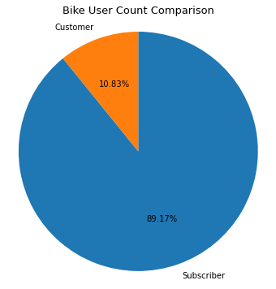

### The relationship between the Number of Trips and duration

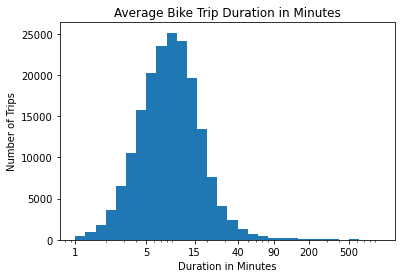

### Impact of gender type on the Duration of the Trip

It can be seen that the male riders have higher trips but the majority others and females have highest trip durations

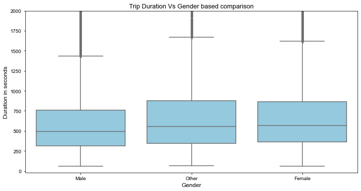

### The impact of Age and member gender on the Duration of the Trip

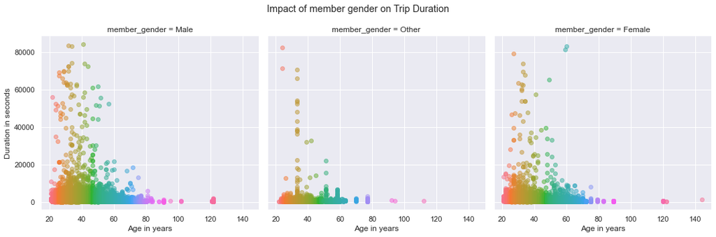

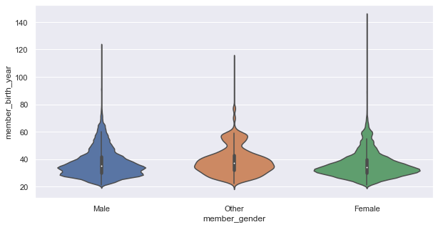

### The impact of Age on the Duration of the Trip

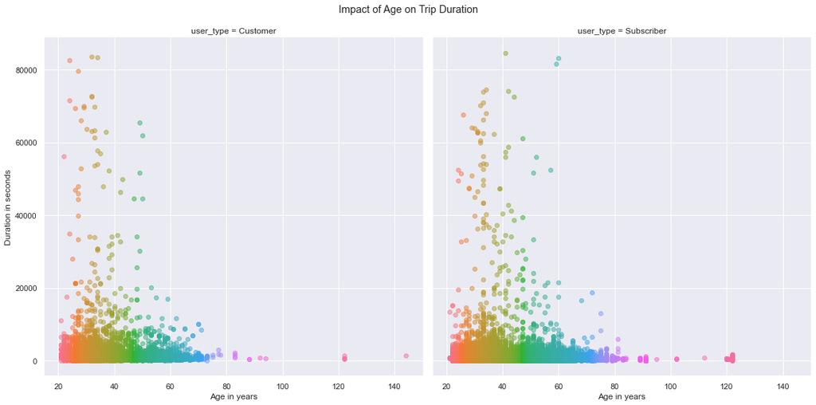

### The impact of start station on the Duration of the Trip

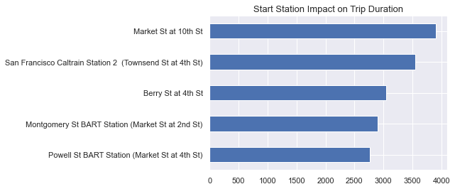

### The impact of end station on the Duration of the Trip

> It can be seen that San Francisco Caltrain Station 2 has the highest number of end trips as compared to the others, which indicates that majority prefare to end their trip there

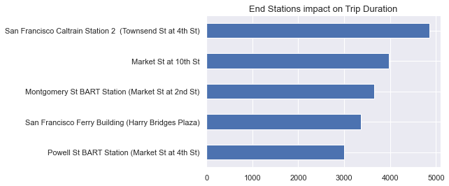